# Cryptocurrency Price Analysis

Authors

Blessing Sekeramavi

Leona Hasani

Leona Hoxha

Nanmanat Disayakamonpan

# 1 Introduction

In this notebook, we explore the historical price trends, volatility, and correlations of various cryptocurrencies. The goal of this project is to identify patterns, analyze financial characteristics, and predict future prices using ARIMA modeling.

```python
import numpy as np  # linear algebra
import pandas as pd  # data processing, CSV file I/O (e.g. pd.read_csv)
import matplotlib.pyplot as plt
import seaborn as sns
from subprocess import check_output

# Configurations
sns.set_theme(style="whitegrid")
color = sns.color_palette()
```

*Code context:* This block imports essential Python libraries used throughout the analysis. numpy and pandas help handle data, while matplotlib and seaborn are for creating visualizations. The seaborn style configuration ensures all plots have a consistent and professional appearance.

## 1.1 Data Overview: Exploratory Data Analysis (EDA)

In this section, we explore the Bitcoin dataset by analyzing its structure, identifying missing values, and understanding the range of dates it covers. This helps establish a foundation for the subsequent analyses.

```python
# Load the Bitcoin dataset
df = pd.read_csv("input/bitcoin_price.csv", parse_dates=["Date"])

# Display basic information about the dataset
print("Dataset Information:")
print(df.info())
print("\n")

# Display descriptive statistics
print("Descriptive Statistics:")
print(df.describe())
print("\n")

# Check for missing values
print("Missing Values in Each Column:")
print(df.isnull().sum())
print("\n")

# Display the range of dates covered in the dataset
start_date = df["Date"].min()
end_date = df["Date"].max()
print(f"The dataset covers the date range: {start_date} to {end_date}")
print("\n")

# Display the first few rows of the dataset for a preview
print("Preview of the Dataset:")
print(df.head())
```

```
Dataset Information:
<class 'pandas.core.frame.DataFrame'>
RangeIndex: 1563 entries, 0 to 1562
Data columns (total 7 columns):
 #   Column      Non-Null Count  Dtype
---  ------      --------------  -----
 0   Date        1563 non-null   datetime64[ns]
 1   Open        1563 non-null   float64
 2   High        1563 non-null   float64
 3   Low         1563 non-null   float64
 4   Close       1563 non-null   float64
 5   Volume      1563 non-null   object
 6   Market Cap  1563 non-null   object
dtypes: datetime64[ns](1), float64(4), object(2)
memory usage: 85.6+ KB
None


Descriptive Statistics:
              Open         High          Low        Close
count  1563.000000  1563.000000  1563.000000  1563.000000
mean    593.120889   608.991919   578.100595   595.042764
std     545.103691   566.299544   527.563414   549.175841
min      68.500000    74.560000    65.530000    68.430000
25%     254.785000   261.070000   249.675000   255.450000
50%     439.980000   448.180000   431.870000   440.220000
75%     665.075000   680.320000   649.635000   665.405000
max    3257.610000  3397.680000  3180.890000  3378.940000


Missing Values in Each Column:
Date          0
Open          0
High          0
Low           0
Close         0
Volume        0
Market Cap    0
dtype: int64


The dataset covers the date range: 2013-04-28 00:00:00 to 2017-08-07 00:00:00


Preview of the Dataset:
        Date     Open     High      Low    Close         Volume  \
0 2017-08-07  3212.78  3397.68  3180.89  3378.94  1,482,280,000
1 2017-08-06  3257.61  3293.29  3155.60  3213.94  1,105,030,000
2 2017-08-05  2897.63  3290.01  2874.83  3252.91  1,945,700,000
3 2017-08-04  2806.93  2899.33  2743.72  2895.89  1,002,120,000
4 2017-08-03  2709.56  2813.31  2685.14  2804.73    804,797,000

       Market Cap
0  52,987,300,000
1  53,720,900,000
2  47,778,200,000
3  46,276,200,000
4  44,666,400,000
```

*Code context:* This block analyzes the Bitcoin dataset’s structure and quality.

- **df.info()** provides an overview of the data, such as column names, types, and non-missing values.
- **df.describe()** calculates statistics like mean, median, and range for numeric columns.
- **Checking for missing values** ensures the data is clean for analysis.
- **df.head()** shows the first few rows, giving a quick preview of the data.

The dataset contains no missing values, spans from 2013-04-28 to 2017-08-07, and provides detailed information on Bitcoin prices, including Open, High, Low, and Close. A preview of the dataset reveals there are no missing values, making it ready for further analysis.

## 1.2 Closing Price Over Time

We visualize the trend of Bitcoin’s closing price over time to understand how its value evolved during the dataset’s time frame.

```python
import plotly.express as px

# Load the Bitcoin dataset
df = pd.read_csv("input/bitcoin_price.csv", parse_dates=["Date"])

# Create an interactive line plot
fig = px.line(
    df,
    x="Date",
    y="Close",
    title="Interactive Closing Price of Bitcoin Over Time",
    labels={"Date": "Date", "Close": "Price in USD"},
    template="plotly_dark"  # Optional: Change the style (e.g., "plotly", "seaborn", "ggplot2")
)

# Customize layout for better readability
fig.update_layout(
    xaxis_title="Date",
    yaxis_title="Price in USD",
    font=dict(family="Arial", size=14, color="white"),
    hovermode="x unified"  # Show a unified tooltip for x-axis
)

# Show the interactive plot
fig.show()
```

[interactive chart not shown]

*Code context:* This block creates an interactive chart showing how Bitcoin’s closing price has changed over time. The plotly.express library makes it easy to create interactive visualizations with hover details. Users can zoom in on specific time periods or hover to see the exact closing price on any given date.

*Cryptocurrency Context:* The “closing price” is the last price at which Bitcoin was traded on a given day, reflecting its market value.

The interactive plot reveals significant volatility in Bitcoin’s price, with notable peaks and troughs, especially toward the dataset’s later years.

## 1.3 Candlestick Chart

To gain a deeper understanding of price fluctuations within specific periods, we use a candlestick chart to analyze Bitcoin’s Open, High, Low, and Close prices.

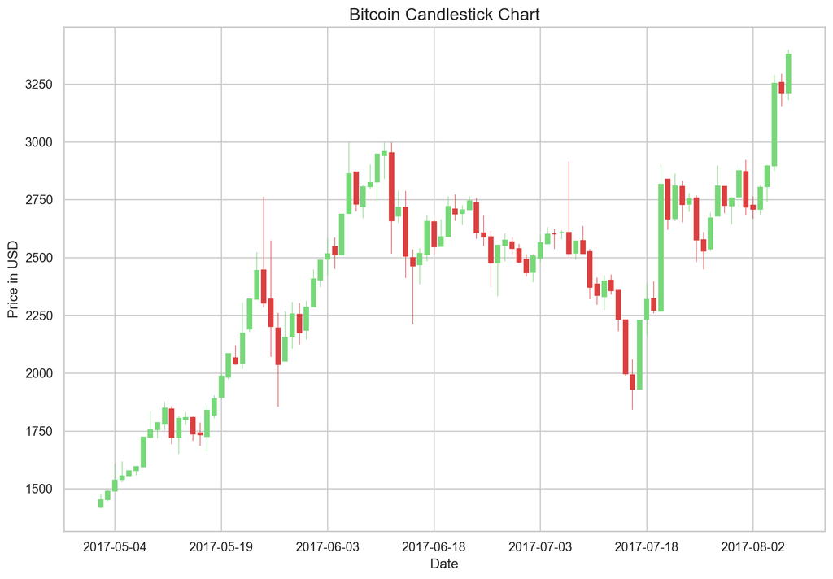

```python
import matplotlib.pyplot as plt
import matplotlib.dates as mdates
import matplotlib.ticker as mticker
from mplfinance.original_flavor import candlestick_ohlc
from matplotlib.dates import date2num

# Convert Date to Matplotlib's numeric date format
df["Date"] = pd.to_datetime(df["Date"])  # Ensure Date is in datetime format
df["Date_mpl"] = df["Date"].apply(date2num)

# Filter recent data
temp_df = df[df["Date"] > "2017-05-01"]
ohlc = temp_df[["Date_mpl", "Open", "High", "Low", "Close"]].values

# Plot candlestick chart
fig, ax = plt.subplots(figsize=(12, 8))
candlestick_ohlc(ax, ohlc, width=0.6, colorup="#77d879", colordown="#db3f3f")
ax.xaxis.set_major_formatter(mdates.DateFormatter("%Y-%m-%d"))
ax.xaxis.set_major_locator(mticker.MaxNLocator(10))
plt.xlabel("Date", fontsize=12)
plt.ylabel("Price in USD", fontsize=12)
plt.title("Bitcoin Candlestick Chart", fontsize=15)
plt.grid(True)
plt.show()
```

*Code Context:* A candlestick chart visualizes the **“Open”**, **“High”**, **“Low”**, and **“Close”** prices of Bitcoin for specific days. Each **“candle”** shows whether the price **increased** *(green)* or **decreased** *(red)* during the day. The chart provides insights into Bitcoin’s price volatility and market sentiment over time.

*Cryptocurrency Context:* Candlestick charts are widely used in trading to identify patterns that might indicate future price movements.

The candlestick chart provides granular insights into Bitcoin’s daily price movements, highlighting periods of intense market activity in mid-2017.

## 1.4 Normalized Price Trends

To compare the performance of different cryptocurrencies over time, we normalize their prices to a base index value of 100.

```python
import plotly.graph_objects as go

# Specify the cryptocurrency files
files_to_use = [
    "bitcoin_price.csv",
    "ethereum_price.csv",
    "ripple_price.csv",
    "litecoin_price.csv"
]

# Load and merge datasets
df_list = []
for file_name in files_to_use:
    currency_name = file_name.split("_")[0]
    temp_df = pd.read_csv(f"input/{file_name}", usecols=["Date", "Close"], parse_dates=["Date"])
    temp_df.rename(columns={"Close": currency_name}, inplace=True)
    df_list.append(temp_df)

# Merge all datasets on the 'Date' column
df_merged = df_list[0]
for temp_df in df_list[1:]:
    df_merged = pd.merge(df_merged, temp_df, on="Date", how="inner")

# Normalize prices to the starting value
df_normalized = df_merged.copy()
cols_to_normalize = df_normalized.columns[1:]  # Exclude 'Date'
df_normalized[cols_to_normalize] = df_normalized[cols_to_normalize].apply(lambda x: x / x.iloc[0] * 100)

# Create an interactive plot with Plotly
fig = go.Figure()

# Add a line for each cryptocurrency
for col in cols_to_normalize:
    fig.add_trace(go.Scatter(
        x=df_normalized["Date"],
        y=df_normalized[col],
        mode='lines',
        name=col.capitalize()
    ))

# Customize layout
fig.update_layout(
    title="Normalized Cryptocurrency Price Trends (Indexed to 100)",
    xaxis_title="Date",
    yaxis_title="Normalized Price (Index=100)",
    template="plotly_dark",  # Optional: Change style
    legend_title="Cryptocurrencies",
    hovermode="x unified"  # Unified hover tooltip
)

# Show the interactive plot
fig.show()
```

[interactive chart not shown]

*Code Context:* Normalizing prices allows us to compare the performance of different cryptocurrencies over time, regardless of their starting price. A starting value of 100 means that all cryptocurrencies begin on equal footing, and their percentage growth or decline can be directly compared.

*Cryptocurrency Context:* Different cryptocurrencies have different market values, but normalization helps analyze relative performance.

We normalized the cryptocurrency data to an index of 100 to establish a common baseline, enabling meaningful comparisons across assets with varying price scales. This approach simplifies analysis by converting price changes into percentage changes, making it easy to observe relative growth or decline over time. For instance, an increase from 100 to 120 reflects a 20% growth, regardless of the original price. This method is widely used in financial analysis to highlight performance trends, compare volatility, and analyze cross-asset behavior, providing clear insights into which cryptocurrencies are outperforming or underperforming relative to others.

## 1.5 Volatility Analysis Code (Interactive)

```python
# Define the cryptocurrency file for volatility analysis (e.g., Bitcoin)
volatility_file = "bitcoin_price.csv"

# Load the dataset
df = pd.read_csv(f"input/{volatility_file}", parse_dates=["Date"])
df.sort_values("Date", inplace=True)  # Ensure data is sorted by date

# Calculate rolling standard deviation (volatility)
rolling_window = 30  # 30-day window for rolling volatility
df["Volatility"] = df["Close"].rolling(window=rolling_window).std()

# Create an interactive plot for volatility using Plotly
import plotly.express as px

fig = px.line(
    df,
    x="Date",
    y="Volatility",
    title=f"{volatility_file.split('_')[0].capitalize()} 30-Day Rolling Volatility",
    labels={"Volatility": "Rolling Volatility", "Date": "Date"},
    template="plotly_white",
)

# Customize layout
fig.update_layout(
    yaxis_title="Volatility (Standard Deviation)",
    xaxis_title="Date",
    hovermode="x unified",  # Unified hover tooltip
    title_font_size=16,
)

# Show the interactive plot
fig.show()
```

[interactive chart not shown]

*Code Context:* Volatility measures how much Bitcoin’s price fluctuates over time. A rolling standard deviation over 30 days captures short-term price changes. High volatility indicates higher risk but also greater potential for significant price changes.

*Cryptocurrency Context:* Cryptocurrencies are known for their volatility, making them both risky and attractive for traders.

## 1.6 ARIMA Forecasting

ARIMA (AutoRegressive Integrated Moving Average) is a powerful model for time series forecasting. In this section, we use ARIMA to predict Bitcoin’s closing prices for the next 30 days based on historical data.

```python
# Define the cryptocurrency file (e.g., Bitcoin) for prediction
prediction_file = "bitcoin_price.csv"

# Load the dataset
df = pd.read_csv(f"input/{prediction_file}", parse_dates=["Date"], index_col="Date")
df.sort_values("Date", inplace=True)  # Ensure the dataset is sorted by date

# We are interested in predicting the "Close" prices, so we'll focus on that
df = df[['Close']]

# Check if the data is stationary (important for ARIMA)
from statsmodels.tsa.stattools import adfuller

result = adfuller(df["Close"].dropna())
print(f"ADF Statistic: {result[0]}")
print(f"p-value: {result[1]}")

# If p-value > 0.05, the series is non-stationary and we need to difference it
# Here, we use 1st differencing if necessary
if result[1] > 0.05:
    df["Close_diff"] = df["Close"].diff().dropna()

    # Recheck stationarity after differencing
    result = adfuller(df["Close_diff"].dropna())
    print(f"ADF Statistic after differencing: {result[0]}")
    print(f"p-value after differencing: {result[1]}")

# Fit the ARIMA model (assuming series is now stationary)
from statsmodels.tsa.arima.model import ARIMA

# Create ARIMA model with p=5, d=1, q=0 (can tune p, d, q values based on ACF and PACF plots)
model = ARIMA(df["Close"], order=(5, 1, 0))
model_fit = model.fit()

# Forecast the next 30 days
forecast_steps = 30
forecast = model_fit.forecast(steps=forecast_steps)

# Prepare the forecasted dates
forecast_dates = pd.date_range(start=df.index[-1], periods=forecast_steps+1, freq="D")[1:]

# Create a DataFrame for the forecast results
forecast_df = pd.DataFrame({
    "Date": forecast_dates,
    "Forecast": forecast
})

# Plot actual vs forecasted prices
import plotly.graph_objects as go

# Actual vs forecasted plot
fig = go.Figure()

# Add actual prices
fig.add_trace(go.Scatter(x=df.index, y=df["Close"], mode='lines', name="Actual Price", line=dict(color="blue")))

# Add forecasted prices
fig.add_trace(go.Scatter(x=forecast_df["Date"], y=forecast_df["Forecast"], mode='lines', name="Forecasted Price", line=dict(color="red", dash="dash")))

# Update layout
fig.update_layout(
    title=f"{prediction_file.split('_')[0].capitalize()} Price Forecast (ARIMA Model)",
    xaxis_title="Date",
    yaxis_title="Price in USD",
    template="plotly_white",
    hovermode="x unified"
)

# Show the interactive plot
fig.show()
```

```
ADF Statistic: 2.852371259150358
p-value: 1.0
ADF Statistic after differencing: -7.083443779072324
p-value after differencing: 4.60287481754251e-10
```

[interactive chart not shown]

*Code Context:* ARIMA, a statistical model used for time series forecasting, predicts future values by leveraging historical data trends. For this task, the parameters order=(5, 1, 0) define the autoregressive (p), differencing (d), and moving average (q) components. This model was used to forecast Bitcoin’s closing price for the next 30 days.

*Cryptocurrency Context:* Cryptocurrency price forecasting aids traders in making more informed decisions. While forecasts can provide valuable insights, the volatile nature of the market necessitates cautious interpretation.

Cryptocurrencies often exhibit interdependencies due to market dynamics. We calculate and visualize the correlations between Bitcoin, Ethereum, Ripple, and Litecoin prices to identify their relationships.

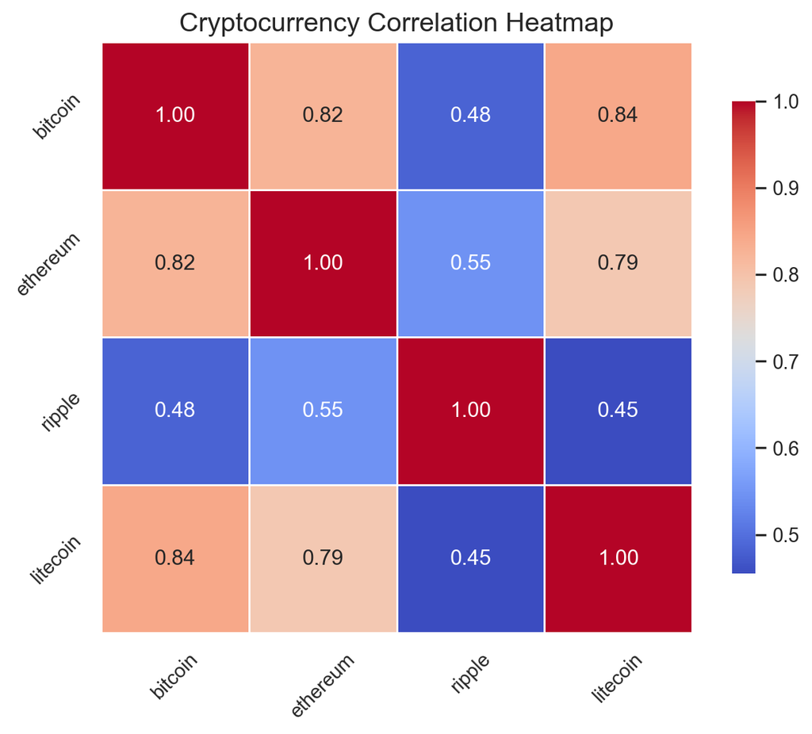

```python
# Specify the files
files_to_use = [
    "bitcoin_price.csv",
    "ethereum_price.csv",
    "ripple_price.csv",
    "litecoin_price.csv"
]

# Load and merge datasets
cols_to_use = []
for i, file_name in enumerate(files_to_use):
    currency_name = file_name.split("_")[0]
    if i == 0:
        df = pd.read_csv(f"input/{file_name}", usecols=["Date", "Close"], parse_dates=["Date"])
        df.columns = ["Date", currency_name]
    else:
        temp_df = pd.read_csv(f"input/{file_name}", usecols=["Date", "Close"], parse_dates=["Date"])
        temp_df.columns = ["Date", currency_name]
        df = pd.merge(df, temp_df, on="Date")
    cols_to_use.append(currency_name)

# Correlation heatmap
corrmat = df[cols_to_use].corr(method="spearman")

# Plot heatmap using Seaborn
plt.figure(figsize=(8, 6))
sns.heatmap(
    corrmat,
    annot=True,
    fmt=".2f",
    cmap="coolwarm",
    linewidths=0.5,
    square=True,
    cbar_kws={"shrink": 0.8}
)
plt.title("Cryptocurrency Correlation Heatmap", fontsize=15)
plt.xticks(rotation=45)
plt.yticks(rotation=45)
plt.show()
```

*Code Context:* This block calculates the correlation between different cryptocurrency prices. A high correlation means the prices tend to move together. A heatmap visually represents these correlations, helping identify relationships between cryptocurrencies.

*Cryptocurrency Context:* Correlation analysis is crucial for portfolio diversification, ensuring assets are not too similar in behavior.

By focusing on Bitcoin as a case study, we have created a correlation heatmap that illustrates its relationships with other cryptocurrencies. This allows us to understand how Bitcoin’s trends might influence or reflect the behavior of other cryptocurrencies. Using this approach, we can extend the analysis to any specific cryptocurrency of interest, enabling deeper insights and a more comprehensive understanding of the cryptocurrency market. The correlation heatmap reveals a strong positive correlation between Bitcoin and Ethereum, Bitcoin and Lifecoin, Ethereum and Lifecoin prices. With ripple, it’s harder to come to conclusions with the help of other cryptopcurrencies, since it is not that highly correlated with any of the other cryptocurrencies. Ripple exhibits moderate correlations with Bitcoin and Ethereum, while Litecoin aligns closely with Bitcoin.

# 2 Conclusion

This analysis explored the historical price trends, volatility, and correlations of cryptocurrencies, focusing on Bitcoin, Ethereum, Ripple, and Litecoin. Through various methods, including exploratory data analysis (EDA), visualization techniques, and time series forecasting, we were able to uncover key insights about cryptocurrency market behavior.

- **Data Overview:** We performed an initial exploration of Bitcoin’s dataset, confirming the absence of missing values and the presence of essential price data spanning from 2013 to 2017. This data was used to create a foundation for the analysis.
- **Price Trends:** The interactive line plot revealed significant fluctuations in Bitcoin’s closing price over time, showcasing the inherent volatility of the cryptocurrency market.
- **Candlestick Chart:** A candlestick chart was employed to provide a more detailed view of daily price movements, highlighting periods of intense market activity, such as mid-2017.
- **Normalized Price Comparison:** By normalizing the prices of multiple cryptocurrencies to an index of 100, we made it easier to compare their performance over time. This analysis indicated how each cryptocurrency grew or declined relative to the others, allowing for a clearer view of their market dynamics.
- **Volatility Analysis:** Using rolling standard deviation, we analyzed the price volatility of Bitcoin over 30-day windows, which is crucial for assessing risk. The volatility plot revealed certain periods of heightened risk, such as mid-2017.
- **ARIMA Forecasting:** The ARIMA model was used to forecast Bitcoin’s closing prices for the next 30 days. We ensured the data was stationary, which is a prerequisite for the ARIMA model. The forecast provided a predictive look at potential future trends in Bitcoin’s price.

Overall, the analysis demonstrates that cryptocurrencies are highly volatile assets, influenced by various market dynamics. The insights gained from this analysis can be applied in making informed decisions regarding cryptocurrency trading, risk assessment, and long-term investment strategies.